# Bay of Biscay and the Iberian Coast

## South-Iberian Atlantic

### Summary

#### Table 1

**Table 1. Values of pressure and impact indicators for 2017‒2022 for three depth strata in the South-Iberian Atlantic subdivision. Values of I‒1, I‒2, I‒3, I‒4, I‒6a, I‒6b, I‒7a and I‒7b are annual means and I‒5 is evaluated over the six years. Descriptions of the pressure and impact indicators are provided in the ‘Essential Information’ Table E1 in this document.**

| Indicators | 0 to 200 m | 200 to 400 m | 400 to 800 m |
| --- | --- | --- | --- |
| I‒1: Average fishing intensity | 0.15 | 1.02 | 0.56 |
| I‒2: Proportion of area fished, evaluated at c-square scale (%) | 27.10 | 55.10 | 61.40 |
| I‒3: Proportion of area fished (%) | 11.20 | 29.50 | 24.20 |
| I‒4: Smallest proportion of area with 90% of fishing intensity, evaluated at c-square scale (%) | 12.30 | 19.30 | 20.40 |
| I‒5: Proportion of area persistently unfished, evaluated at c-square scale (%) | 72.90 | 44.90 | 38.60 |
| I‒6a: Average PD impact | 0.50 | 3.80 | 2.60 |
| I‒6b: Average PD-sens impact | 0.70 | 4.20 | 3.10 |
| I‒7a: Proportion of area with PD impact < 0.2, evaluated at c-square scale (%) | 99.70 | 97.90 | 97.10 |
| I‒7b: Proportion of area with PD-sens impact < 0.2, evaluated at c-square scale (%) | 99.70 | 97.40 | 96.30 |

#### Figure 1

**Figure 1. Geographic distribution of fishing intensity (swept area ratio), seabed sensitivity (community longevity), total landings value, and total landings weight from mobile bottom-contacting gear (MBCG) in the South-Iberian Atlantic subdivision. The maps of swept area ratio, landings value, and landings weight show annual means evaluated at the c-square scale.**

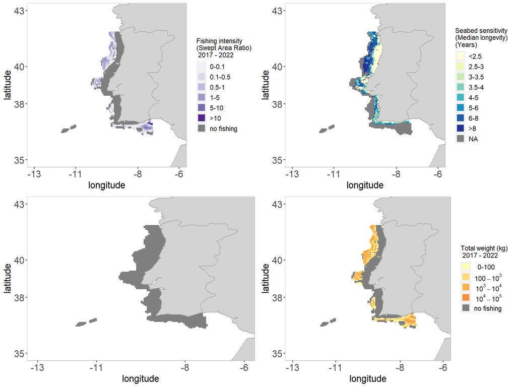

#### Table 2

**Table 2. Contribution of small-scale fisheries (vessels < 12 m overall length) to total fishing effort (kW × fishing days) in the South-Iberian Atlantic subdivision. The table shows the total fishing effort (kW × fishing days) by FAO region over the assessment period, and the mean contribution (%) and observed range in contribution (%) of small-scale MBCG fisheries’.**

| FAO region code | FAO region name | Total fishing effort (kW × Fishing days) | Mean contribution SSF (%) | Observed range SSF contribution (%) [min - max] |
| --- | --- | --- | --- | --- |
| 27.9.a | Portuguese Waters - East | 7567817 | 23.2 | [2 - 34] |

### Fishing intensity

#### Table 3

**Table 3. Extent (in km<sup>2</sup> and %) of broad habitat types in the South-Iberian Atlantic subdivision, and mean annual estimates of MBCG fishing intensity, landings weight, and landings value. In addition, estimates of the average annual proportion of the fished extent, the smallest proportion of the habitat extent affected by 90% of the fishing effort, and the proportion of extent persistently unfished are provided.**

| MSFD broad habitat type | Extent of habitat (×1000 km<sup>2</sup>) | Relative habitat extent (%) | Landings (×1000 tonnes) | Value (×10<sup>6</sup> euro) | Swept area (×1000 km<sup>2</sup>) | Average fishing intensity (I‒1) | Average annual extent fished (%) | Smallest proportion of extent with 90% of fishing effort (%) | Percentage extent persistently unfished (%) |
| --- | --- | --- | --- | --- | --- | --- | --- | --- | --- |
| Offshore circalittoral mud | 8.72 | 23.7 | 0.35 | NA | 3.44 | 0.39 | 18.0 | 17.2 | 58.4 |
| Upper bathyal sediment or Upper bathyal rock and biogenic reef | 6.93 | 18.8 | 0.35 | NA | 3.54 | 0.51 | 23.9 | 21.9 | 40.6 |
| Upper bathyal sediment | 6.04 | 16.4 | 0.58 | NA | 5.07 | 0.84 | 31.8 | 25.3 | 35.6 |
| Circalittoral sand | 2.95 | 8.0 | 0.00 | NA | 0.02 | 0.01 | 0.7 | 2.3 | 95.1 |
| Circalittoral mixed sediment | 2.49 | 6.8 | 0.00 | NA | 0.02 | 0.01 | 0.6 | 2.7 | 90.9 |
| Offshore circalittoral sand | 2.26 | 6.1 | 0.18 | NA | 1.09 | 0.48 | 33.2 | 33.4 | 46.3 |
| Offshore circalittoral rock and biogenic reef | 1.95 | 5.3 | 0.04 | NA | 0.33 | 0.17 | 14.7 | 30.8 | 42.7 |
| Circalittoral mud | 1.77 | 4.8 | 0.00 | NA | 0.02 | 0.01 | 1.2 | 1.0 | 93.9 |
| Circalittoral rock and biogenic reef | 1.64 | 4.4 | 0.00 | NA | 0.02 | 0.01 | 1.1 | 3.2 | 93.5 |
| Offshore circalittoral mixed sediment | 0.64 | 1.7 | 0.02 | NA | 0.22 | 0.34 | 8.0 | 6.7 | 70.5 |
| Infralittoral sand | 0.62 | 1.7 | 0.00 | NA | 0.00 | 0.00 | 0.0 | 0.0 | 99.9 |
| Upper bathyal rock and biogenic reef | 0.24 | 0.7 | 0.00 | NA | 0.03 | 0.10 | 9.1 | 19.8 | 67.6 |
| Infralittoral rock and biogenic reef | 0.21 | 0.6 | 0.00 | NA | 0.00 | 0.00 | 0.0 | 0.0 | 99.8 |
| Unknown | 0.15 | 0.4 | 0.00 | NA | 0.01 | 0.06 | 5.2 | 4.9 | 94.0 |
| Lower bathyal sediment or Lower bathyal rock and biogenic reef | 0.10 | 0.3 | 0.00 | NA | 0.01 | 0.12 | 11.7 | 27.7 | 32.0 |
| Infralittoral mixed sediment | 0.06 | 0.2 | 0.00 | NA | 0.00 | 0.00 | 0.0 | 0.0 | 97.5 |
| Offshore circalittoral coarse sediment | 0.05 | 0.1 | 0.00 | NA | 0.00 | 0.09 | 8.5 | 5.3 | 87.2 |
| Infralittoral mud | 0.05 | 0.1 | 0.00 | NA | 0.00 | 0.00 | 0.0 | 0.0 | 97.6 |
| Abyssal | 0.00 | 0.0 | 0.00 | NA | 0.00 | 0.00 | 0.4 | NA | 58.3 |
| Circalittoral coarse sediment | 0.00 | 0.0 | 0.00 | NA | 0.00 | 0.00 | 0.0 | NA | 100.0 |
| Lower bathyal sediment | 0.00 | 0.0 | 0.00 | NA | 0.00 | 0.00 | 0.0 | NA | 100.0 |

#### Figure 2

**Figure 2. Temporal variation of the pressure indicators I‒1, I‒3 and I‒4 in the South-Iberian Atlantic subdivision. Descriptions of the pressure indicators are provided in the ‘Essential Information’ Table E1 in this document.**

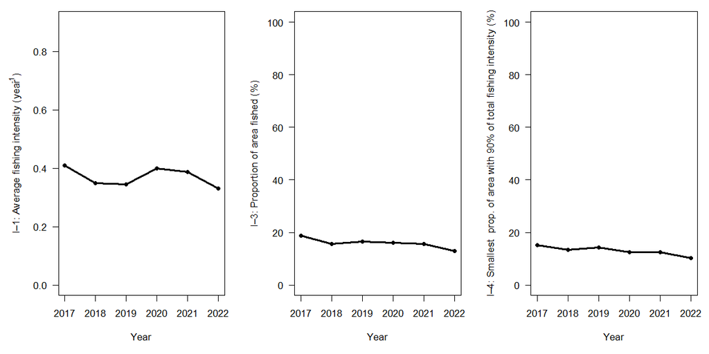

### Fishing by métier

#### Table 4

**Table 4. Landings weight and value by métier and their relationship with swept area in the South-Iberian Atlantic subdivision.**

|  | OT_CRU | OT_DMF | OT_MI |
| --- | --- | --- | --- |
| Area swept (×1000 km<sup>2</sup>) | 7.8 | 5.94 | 0.09 |
| Landings (×1000 tonnes) | 0.6 | 0.88 | 0.06 |
| Value (×10<sup>6</sup> euro) | NA | NA | NA |
| Landings / Area swept (kg/km<sup>2</sup>) | 77.4 | 147.65 | 666.41 |
| Value / Area swept (euro/km<sup>2</sup>) | NA | NA | NA |

### Core fishing grounds

**Core fishing grounds could not be identified in this subdivision.**

### Impact

#### Figure 5

**Figure 5. The spatial distribution of MBCG fisheries impact in the South-Iberian Atlantic subdivision, as assessed with the PD indicator (I‒6a) and PD-sens indicator (I‒6b), shown as annual means for the assessment period, evaluated at the c-square scale. Descriptions of the impact indicators are provided in the ‘Essential Information’ Table E1 in this document.**

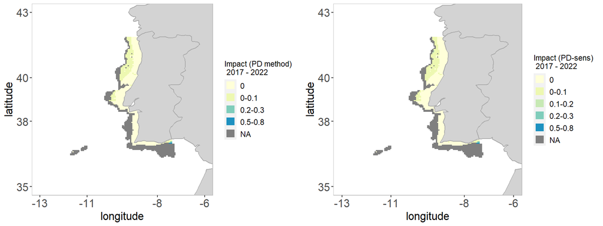

#### Figure 6

**Figure 6. Temporal variation in values of the PD indicator (I‒6a), PD-sens indicator (I‒6b), proportion of the extent with PD impact < 0.2 (I‒7a) and proportion of extent with PD-sens impact < 0.2 (I‒7b), shown for the overall area and for the four most extensive broad habitat types separately in the South-Iberian Atlantic subdivision. Descriptions of the impact indicators are provided in the ‘Essential Information’ Table E1 in this document.**

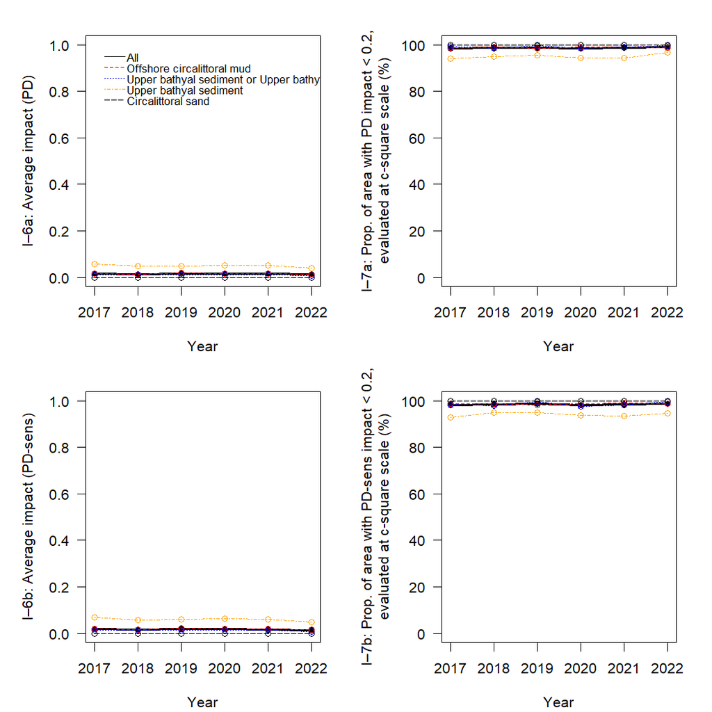

#### Table 5

**Table 5. Métier-specific landings weight and value per unit PD or PD-sens impact in the South-Iberian Atlantic subdivision.**

|  | OT_CRU | OT_DMF | OT_MI |
| --- | --- | --- | --- |
| Landings (tonnes)/PD impact | 7.3 | 29.4 | 29.6 |
| Value (×1000 euro)/PD impact | NA | NA | NA |
| Landings (tonnes)/PD-sens impact | 7.0 | 27.7 | 28.5 |
| Value (×1000 euro)/PD-sens impact | NA | NA | NA |

#### Figure 7

**Figure 7. Métier-related impacts, reported as annual means of the PD indicator (I‒6a, top) and PD-sens indicator (I‒6b, bottom), on the four most extensive broad habitat types in the South-Iberian Atlantic subdivision.**

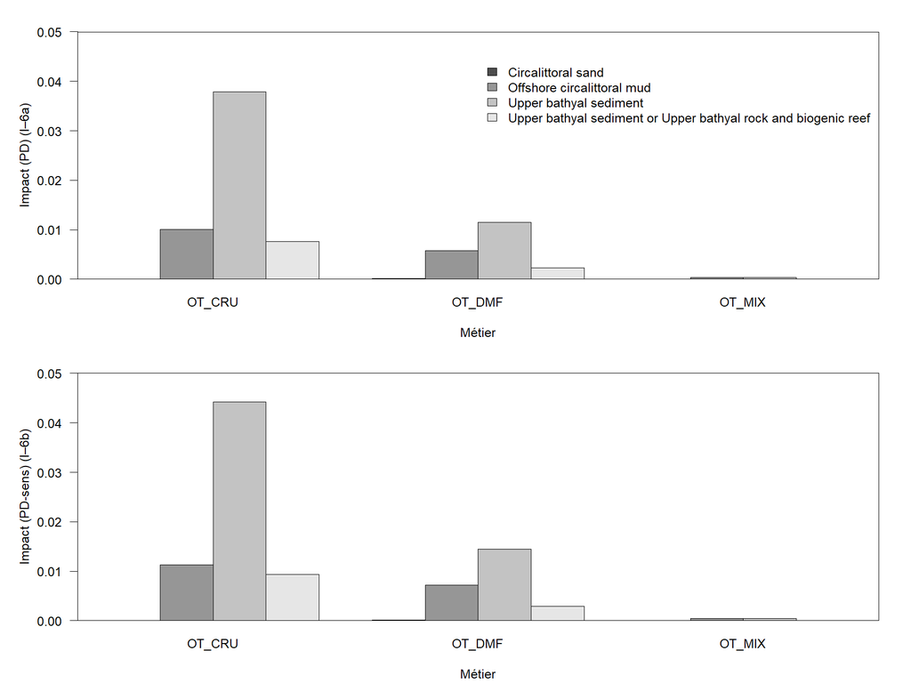

### Scenarios

#### Footprint reduction

##### Table 6: Effort

**Table 6. The effects of stepwise exclusion of all MBCG fisheries from a specified proportion of a MSFD broad habitat type within the South-Iberian Atlantic subdivision, on swept area (presented as % of total swept area within that habitat type). The stepwise exclusion is conducted in 10% increments, and within each successive increment from 10% to 90% the c-squares with the lowest recorded rank MBCG swept area are excluded. Note that the top row shows the total estimate for all habitats combined.**

| MSFD broad habitat type | Extent of habitat (×1000 km<sup>2</sup>) | Total area swept (×1000 km<sup>2</sup> | 10% | 20% | 30% | 40% | 50% | 60% | 70% | 80% | 90% |
| --- | --- | --- | --- | --- | --- | --- | --- | --- | --- | --- | --- |
| total | 36.87 | 100 | 0.0 | 0.0 | 0.0 | <0.1 | 0.3 | 1.7 | 5.6 | 14.0 | 32.7 |
| Offshore circalittoral mud | 8.72 | 3.44 | 0.0 | 0.0 | 0.0 | 0.0 | 0.0 | <0.1 | 1.7 | 7.2 | 23.9 |
| Upper bathyal sediment or Upper bathyal rock and biogenic reef | 6.93 | 3.54 | 0.0 | 0.0 | 0.0 | 0.0 | 0.2 | 1.3 | 4.9 | 12.0 | 32.1 |
| Upper bathyal sediment | 6.04 | 5.07 | 0.0 | 0.0 | 0.0 | <0.1 | 0.6 | 2.4 | 6.7 | 15.8 | 34.2 |
| Circalittoral sand | 2.95 | 0.02 | 0.0 | 0.0 | 0.0 | 0.0 | 0.0 | 0.0 | 0.0 | 0.0 | 0.0 |
| Circalittoral mixed sediment | 2.49 | 0.02 | 0.0 | 0.0 | 0.0 | 0.0 | 0.0 | 0.0 | 0.0 | 0.0 | 0.0 |
| Offshore circalittoral sand | 2.26 | 1.09 | 0.0 | 0.0 | 0.0 | 0.0 | 0.3 | 4.0 | 14.1 | 33.9 | 58.5 |
| Offshore circalittoral rock and biogenic reef | 1.95 | 0.33 | 0.0 | 0.0 | 0.0 | 0.0 | 0.8 | 4.6 | 11.5 | 22.8 | 46.0 |
| Circalittoral mud | 1.77 | 0.02 | 0.0 | 0.0 | 0.0 | 0.0 | 0.0 | 0.0 | 0.0 | 0.0 | 0.0 |
| Circalittoral rock and biogenic reef | 1.64 | 0.02 | 0.0 | 0.0 | 0.0 | 0.0 | 0.0 | 0.0 | 0.0 | 0.0 | 0.0 |
| Offshore circalittoral mixed sediment | 0.64 | 0.22 | 0.0 | 0.0 | 0.0 | 0.0 | 0.0 | 0.0 | 0.0 | 0.8 | 7.4 |
| Infralittoral sand | 0.62 | 0 | 0.0 | 0.0 | 0.0 | 0.0 | 0.0 | 0.0 | 0.0 | 0.0 | 0.0 |
| Upper bathyal rock and biogenic reef | 0.24 | 0.03 | 0.0 | 0.0 | 0.0 | 0.0 | 0.0 | 0.0 | 0.3 | 10.9 | 54.8 |
| Infralittoral rock and biogenic reef | 0.21 | 0 | 0.0 | 0.0 | 0.0 | 0.0 | 0.0 | 0.0 | 0.0 | 0.0 | 0.0 |
| Unknown | 0.15 | 0.01 | 0.0 | 0.0 | 0.0 | 0.0 | 0.0 | 0.0 | 0.0 | 0.0 | 0.0 |
| Lower bathyal sediment or Lower bathyal rock and biogenic reef | 0.1 | 0.01 | 0.0 | 0.0 | 0.0 | 3.5 | 6.5 | 6.5 | 10.4 | 41.9 | 78.9 |
| Infralittoral mixed sediment | 0.06 | 0 | 0.0 | 0.0 | 0.0 | 0.0 | 0.0 | 0.0 | 0.0 | 0.0 | 0.0 |
| Offshore circalittoral coarse sediment | 0.05 | 0 | 0.0 | 0.0 | 0.0 | 0.0 | 0.0 | 0.0 | 0.0 | 0.0 | 34.5 |
| Infralittoral mud | 0.05 | 0 | 0.0 | 0.0 | 0.0 | 0.0 | 0.0 | 0.0 | 0.0 | 0.0 | 0.0 |
| Abyssal | 0 | 0 | 0.0 | 0.0 | 0.0 | 0.0 | 0.0 | 100.0 | 100.0 | 100.0 | 100.0 |
| Circalittoral coarse sediment | 0 | 0 | NaN | NaN | NaN | NaN | NaN | NaN | NaN | NaN | NaN |
| Lower bathyal sediment | 0 | 0 | NaN | NaN | NaN | NaN | NaN | NaN | NaN | NaN | NaN |

##### Table 7: Landings weight

**Table 7. The effects of stepwise exclusion of all MBCG fisheries from a specified proportion of a MSFD broad habitat type within the South-Iberian Atlantic subdivision, on landings weight (presented as % of total landings weight within that habitat type). The stepwise exclusion is conducted in 10% increments, and within each successive increment from 10% to 90% the c-squares with the lowest recorded rank MBCG swept area are excluded. Note that the top row shows the total estimate for all habitats combined.**

| MSFD broad habitat type | Extent of habitat (×1000 km<sup>2</sup>) | Total landings weight (×1000 kg) | 10% | 20% | 30% | 40% | 50% | 60% | 70% | 80% | 90% |
| --- | --- | --- | --- | --- | --- | --- | --- | --- | --- | --- | --- |
| Total | 36.87 | 1539.1 | 0.0 | 0.0 | 0.0 | <0.1 | 0.3 | 1.8 | 6.4 | 15.5 | 38.6 |
| Offshore circalittoral mud | 8.72 | 352.5 | 0.0 | 0.0 | 0.0 | 0.0 | 0.0 | 0.1 | 2.0 | 8.8 | 29.8 |
| Upper bathyal sediment or Upper bathyal rock and biogenic reef | 6.93 | 347.6 | 0.0 | 0.0 | 0.0 | 0.0 | 0.2 | 1.7 | 6.2 | 14.2 | 37.9 |
| Upper bathyal sediment | 6.04 | 578 | 0.0 | 0.0 | 0.0 | <0.1 | 0.5 | 2.3 | 7.3 | 16.3 | 42.7 |
| Circalittoral sand | 2.95 | 2.8 | 0.0 | 0.0 | 0.0 | 0.0 | 0.0 | 0.0 | 0.0 | 0.0 | 0.0 |
| Circalittoral mixed sediment | 2.49 | 1.7 | 0.0 | 0.0 | 0.0 | 0.0 | 0.0 | 0.0 | 0.0 | 0.0 | 0.0 |
| Offshore circalittoral sand | 2.26 | 183.9 | 0.0 | 0.0 | 0.0 | 0.0 | 0.2 | 3.4 | 12.2 | 28.6 | 46.6 |
| Offshore circalittoral rock and biogenic reef | 1.95 | 44.7 | 0.0 | 0.0 | 0.0 | 0.0 | 0.9 | 4.0 | 11.1 | 21.8 | 44.9 |
| Circalittoral mud | 1.77 | 1.3 | 0.0 | 0.0 | 0.0 | 0.0 | 0.0 | 0.0 | 0.0 | 0.0 | 0.0 |
| Circalittoral rock and biogenic reef | 1.64 | 2.5 | 0.0 | 0.0 | 0.0 | 0.0 | 0.0 | 0.0 | 0.0 | 0.0 | 0.0 |
| Offshore circalittoral mixed sediment | 0.64 | 17.9 | 0.0 | 0.0 | 0.0 | 0.0 | 0.0 | 0.0 | 0.0 | 1.1 | 9.4 |
| Infralittoral sand | 0.62 | 0 | 0.0 | 0.0 | 0.0 | 0.0 | 0.0 | 0.0 | 0.0 | 0.0 | 0.0 |
| Upper bathyal rock and biogenic reef | 0.24 | 2.9 | 0.0 | 0.0 | 0.0 | 0.0 | 0.0 | 0.0 | 0.3 | 9.0 | 52.2 |
| Infralittoral rock and biogenic reef | 0.21 | 0 | 0.0 | 0.0 | 0.0 | 0.0 | 0.0 | 0.0 | 0.0 | 0.0 | 0.0 |
| Unknown | 0.15 | 1.1 | 0.0 | 0.0 | 0.0 | 0.0 | 0.0 | 0.0 | 0.0 | 0.0 | 0.0 |
| Lower bathyal sediment or Lower bathyal rock and biogenic reef | 0.1 | 1.6 | 0.0 | 0.0 | 0.0 | 2.7 | 5.9 | 5.9 | 9.3 | 42.6 | 76.2 |
| Infralittoral mixed sediment | 0.06 | 0 | 0.0 | 0.0 | 0.0 | 0.0 | 0.0 | 0.0 | 0.0 | 0.0 | 0.0 |
| Offshore circalittoral coarse sediment | 0.05 | 0.6 | 0.0 | 0.0 | 0.0 | 0.0 | 0.0 | 0.0 | 0.0 | 0.0 | 26.8 |
| Infralittoral mud | 0.05 | 0 | 0.0 | 0.0 | 0.0 | 0.0 | 0.0 | 0.0 | 0.0 | 0.0 | 0.0 |
| Abyssal | 0 | 0 | 0.0 | 0.0 | 0.0 | 0.0 | 0.0 | 100.0 | 100.0 | 100.0 | 100.0 |
| Circalittoral coarse sediment | 0 | 0 | NaN | NaN | NaN | NaN | NaN | NaN | NaN | NaN | NaN |
| Lower bathyal sediment | 0 | 0 | NaN | NaN | NaN | NaN | NaN | NaN | NaN | NaN | NaN |

##### Table 8: Landings value

**Table 8. The effects of stepwise exclusion of all MBCG fisheries from a specified proportion of a MSFD broad habitat type within the South-Iberian Atlantic subdivision, on landings value (presented as % of total landings value within that habitat type). The stepwise exclusion is conducted in 10% increments, and within each successive increment from 10% to 90% the c-squares with the lowest recorded rank MBCG swept area are excluded. Note that the top row shows the total estimate for all habitats combined.**

| MSFD broad habitat type | Extent of habitat (×1000 km<sup>2</sup>) | Total landings value (×1000 euro) | 10% | 20% | 30% | 40% | 50% | 60% | 70% | 80% | 90% |
| --- | --- | --- | --- | --- | --- | --- | --- | --- | --- | --- | --- |
| Total | 36.87 | NA | NA | NA | NA | NA | NA | NA | NA | NA | NA |
| Offshore circalittoral mud | 8.72 | NA | NA | NA | NA | NA | NA | NA | NA | NA | NA |
| Upper bathyal sediment or Upper bathyal rock and biogenic reef | 6.93 | NA | NA | NA | NA | NA | NA | NA | NA | NA | NA |
| Upper bathyal sediment | 6.04 | NA | NA | NA | NA | NA | NA | NA | NA | NA | NA |
| Circalittoral sand | 2.95 | NA | NA | NA | NA | NA | NA | NA | NA | NA | NA |
| Circalittoral mixed sediment | 2.49 | NA | NA | NA | NA | NA | NA | NA | NA | NA | NA |
| Offshore circalittoral sand | 2.26 | NA | NA | NA | NA | NA | NA | NA | NA | NA | NA |
| Offshore circalittoral rock and biogenic reef | 1.95 | NA | NA | NA | NA | NA | NA | NA | NA | NA | NA |
| Circalittoral mud | 1.77 | NA | NA | NA | NA | NA | NA | NA | NA | NA | NA |
| Circalittoral rock and biogenic reef | 1.64 | NA | NA | NA | NA | NA | NA | NA | NA | NA | NA |
| Offshore circalittoral mixed sediment | 0.64 | NA | NA | NA | NA | NA | NA | NA | NA | NA | NA |
| Infralittoral sand | 0.62 | NA | NA | NA | NA | NA | NA | NA | NA | NA | NA |
| Upper bathyal rock and biogenic reef | 0.24 | NA | NA | NA | NA | NA | NA | NA | NA | NA | NA |
| Infralittoral rock and biogenic reef | 0.21 | NA | NA | NA | NA | NA | NA | NA | NA | NA | NA |
| Unknown | 0.15 | NA | NA | NA | NA | NA | NA | NA | NA | NA | NA |
| Lower bathyal sediment or Lower bathyal rock and biogenic reef | 0.1 | NA | NA | NA | NA | NA | NA | NA | NA | NA | NA |
| Infralittoral mixed sediment | 0.06 | NA | NA | NA | NA | NA | NA | NA | NA | NA | NA |
| Offshore circalittoral coarse sediment | 0.05 | NA | NA | NA | NA | NA | NA | NA | NA | NA | NA |
| Infralittoral mud | 0.05 | NA | NA | NA | NA | NA | NA | NA | NA | NA | NA |
| Abyssal | 0 | NA | NA | NA | NA | NA | NA | NA | NA | NA | NA |
| Circalittoral coarse sediment | 0 | NA | NA | NA | NA | NA | NA | NA | NA | NA | NA |
| Lower bathyal sediment | 0 | NA | NA | NA | NA | NA | NA | NA | NA | NA | NA |

#### Gear modifications

##### Figure 8: Habitat 1

**Figure 8. Effects of gear modifications (5%, 10%, and 20% lower depletion) on the quality-extent relationship for the most abundant MSFD habitat type in the South-Iberian Atlantic subdivision. Habitat quality is defined as 1 - impact, with impact calculated as PD (I‒6a) or PD-sens (I‒7a). The dotted line represent the extent threshold of 75% for the proportion of a broad habitat type that should not be adversely affected (EU, 2024).**

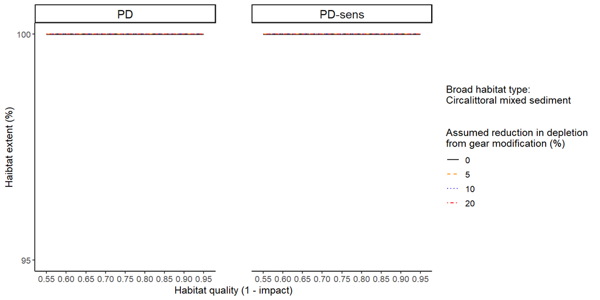

##### Figure 9: Habitat 2

**Figure 9. Effects of gear modifications (5%, 10%, and 20% lower depletion) on the quality-extent relationship for the most abundant MSFD habitat type in the South-Iberian Atlantic subdivision. Habitat quality is defined as 1 - impact, with impact calculated as PD (I‒6a) or PD-sens (I‒7a). The dotted line represent the extent threshold of 75% for the proportion of a broad habitat type that should not be adversely affected (EU, 2024).**

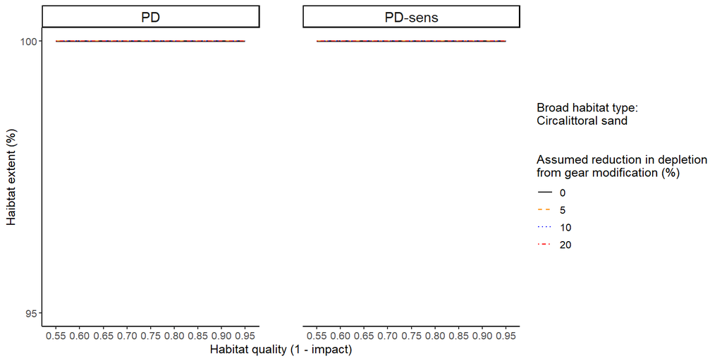

##### Figure 10: Habitat 3

**Figure 10. Effects of gear modifications (5%, 10%, and 20% lower depletion) on the quality-extent relationship for the most abundant MSFD habitat type in the South-Iberian Atlantic subdivision. Habitat quality is defined as 1 - impact, with impact calculated as PD (I‒6a) or PD-sens (I‒7a). The dotted line represent the extent threshold of 75% for the proportion of a broad habitat type that should not be adversely affected (EU, 2024).**

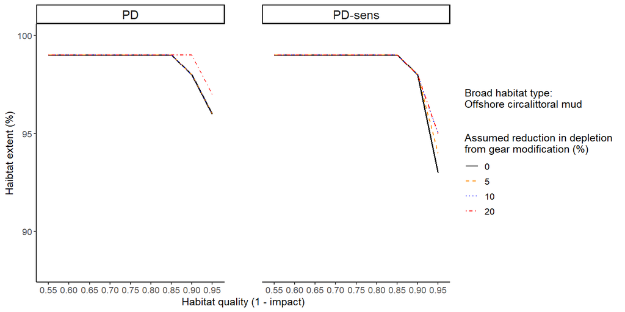

##### Figure 11: Habitat 4

**Figure 11. Effects of gear modifications (5%, 10%, and 20% lower depletion) on the quality-extent relationship for the most abundant MSFD habitat type in the South-Iberian Atlantic subdivision. Habitat quality is defined as 1 - impact, with impact calculated as PD (I‒6a) or PD-sens (I‒7a). The dotted line represent the extent threshold of 75% for the proportion of a broad habitat type that should not be adversely affected (EU, 2024).**

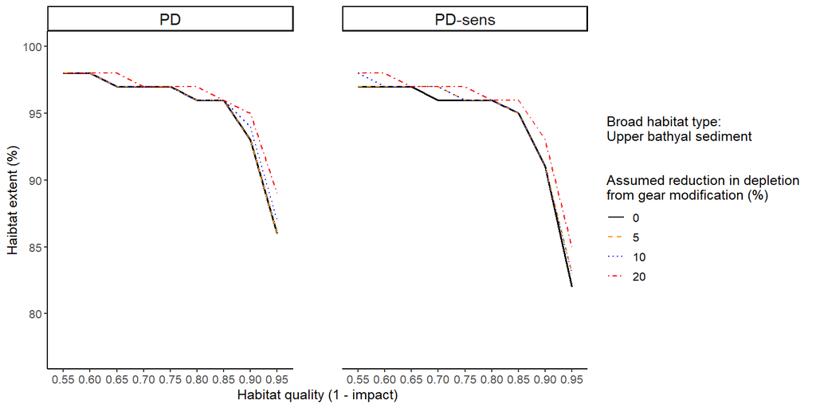

## Gulf of Cadiz

### Summary

#### Table 1

**Table 1. Values of pressure and impact indicators for 2017‒2022 for three depth strata in the Gulf of Cadiz subdivision. Values of I‒1, I‒2, I‒3, I‒4, I‒6a, I‒6b, I‒7a and I‒7b are annual means and I‒5 is evaluated over the six years. Descriptions of the pressure and impact indicators are provided in the ‘Essential Information’ Table E1 in this document.**

| Indicators | 0 to 200 m | 200 to 400 m | 400 to 800 m |
| --- | --- | --- | --- |
| I‒1: Average fishing intensity | 8.51 | 9.0 | 1.06 |
| I‒2: Proportion of area fished, evaluated at c-square scale (%) | 85.40 | 100.0 | 52.70 |
| I‒3: Proportion of area fished (%) | 67.60 | 90.7 | 39.10 |
| I‒4: Smallest proportion of area with 90% of fishing intensity, evaluated at c-square scale (%) | 39.30 | 46.9 | 28.30 |
| I‒5: Proportion of area persistently unfished, evaluated at c-square scale (%) | 14.60 | 0.0 | 47.30 |
| I‒6a: Average PD impact | 36.60 | 47.3 | 11.80 |
| I‒6b: Average PD-sens impact | 40.20 | 51.7 | 14.60 |
| I‒7a: Proportion of area with PD impact < 0.2, evaluated at c-square scale (%) | 50.10 | 33.4 | 78.80 |
| I‒7b: Proportion of area with PD-sens impact < 0.2, evaluated at c-square scale (%) | 51.10 | 29.5 | 74.10 |

#### Figure 1

**Figure 1. Geographic distribution of fishing intensity (swept area ratio), seabed sensitivity (community longevity), total landings value, and total landings weight from mobile bottom-contacting gear (MBCG) in the Gulf of Cadiz subdivision. The maps of swept area ratio, landings value, and landings weight show annual means evaluated at the c-square scale.**

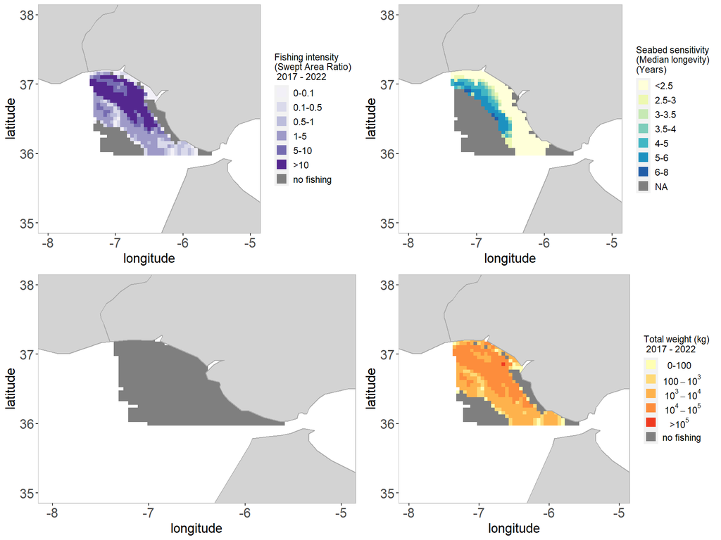

#### Table 2

**Table 2. Contribution of small-scale fisheries (vessels < 12 m overall length) to total fishing effort (kW × fishing days) in the Gulf of Cadiz subdivision. The table shows the total fishing effort (kW × fishing days) by FAO region over the assessment period, and the mean contribution (%) and observed range in contribution (%) of small-scale MBCG fisheries’.**

| FAO region code | FAO region name | Total fishing effort (kW × Fishing days) | Mean contribution SSF (%) | Observed range SSF contribution (%) [min - max] |
| --- | --- | --- | --- | --- |
| 27.9.a | Portuguese Waters - East | 7567817 | 23.2 | [2 - 34] |

### Fishing intensity

#### Table 3

**Table 3. Extent (in km<sup>2</sup> and %) of broad habitat types in the Gulf of Cadiz subdivision, and mean annual estimates of MBCG fishing intensity, landings weight, and landings value. In addition, estimates of the average annual proportion of the fished extent, the smallest proportion of the habitat extent affected by 90% of the fishing effort, and the proportion of extent persistently unfished are provided.**

| MSFD broad habitat type | Extent of habitat (×1000 km<sup>2</sup>) | Relative habitat extent (%) | Landings (×1000 tonnes) | Value (×10<sup>6</sup> euro) | Swept area (×1000 km<sup>2</sup>) | Average fishing intensity (I‒1) | Average annual extent fished (%) | Smallest proportion of extent with 90% of fishing effort (%) | Percentage extent persistently unfished (%) |
| --- | --- | --- | --- | --- | --- | --- | --- | --- | --- |
| Upper bathyal sediment | 4.08 | 37.1 | 0.96 | NA | 11.62 | 2.85 | 52.3 | 33.4 | 35.6 |
| Circalittoral sand | 1.79 | 16.3 | 0.80 | NA | 10.51 | 5.87 | 59.7 | 34.0 | 19.2 |
| Circalittoral mud | 1.72 | 15.6 | 1.71 | NA | 25.68 | 14.95 | 88.8 | 65.8 | 2.6 |
| Offshore circalittoral mud | 1.28 | 11.6 | 1.45 | NA | 20.81 | 16.28 | 100.0 | 77.1 | 0.0 |
| Offshore circalittoral sand | 0.57 | 5.2 | 0.08 | NA | 0.94 | 1.65 | 86.2 | 72.8 | 0.0 |
| Infralittoral sand | 0.44 | 4.0 | 0.07 | NA | 0.63 | 1.44 | 18.1 | 6.5 | 37.6 |
| Circalittoral mixed sediment | 0.15 | 1.4 | 0.14 | NA | 1.64 | 11.24 | 93.2 | 52.9 | 0.6 |
| Infralittoral rock and biogenic reef | 0.14 | 1.3 | 0.00 | NA | 0.01 | 0.05 | 4.6 | 9.2 | 89.1 |
| Circalittoral rock and biogenic reef | 0.13 | 1.2 | 0.01 | NA | 0.05 | 0.38 | 19.1 | 20.5 | 61.1 |
| Infralittoral mixed sediment | 0.13 | 1.2 | 0.02 | NA | 0.20 | 1.53 | 33.4 | 20.8 | 2.3 |
| Upper bathyal rock and biogenic reef | 0.12 | 1.1 | 0.01 | NA | 0.09 | 0.70 | 35.5 | 30.1 | 39.0 |
| Infralittoral mud | 0.12 | 1.1 | 0.02 | NA | 0.04 | 0.37 | 9.3 | 5.5 | 33.7 |
| Infralittoral coarse sediment | 0.10 | 0.9 | 0.02 | NA | 0.10 | 0.97 | 31.5 | 25.4 | 21.3 |
| Circalittoral coarse sediment | 0.10 | 0.9 | 0.03 | NA | 0.27 | 2.70 | 77.1 | 61.6 | 5.1 |
| Offshore circalittoral coarse sediment | 0.08 | 0.7 | 0.02 | NA | 0.25 | 3.10 | 66.3 | 40.3 | 0.0 |
| Offshore circalittoral mixed sediment | 0.06 | 0.5 | 0.10 | NA | 1.44 | 25.28 | 100.0 | 83.8 | 0.0 |
| Unknown | 0.00 | 0.0 | 0.00 | NA | 0.00 | 0.01 | 1.2 | NA | 61.3 |

#### Figure 2

**Figure 2. Temporal variation of the pressure indicators I‒1, I‒3 and I‒4 in the Gulf of Cadiz subdivision. Descriptions of the pressure indicators are provided in the ‘Essential Information’ Table E1 in this document.**

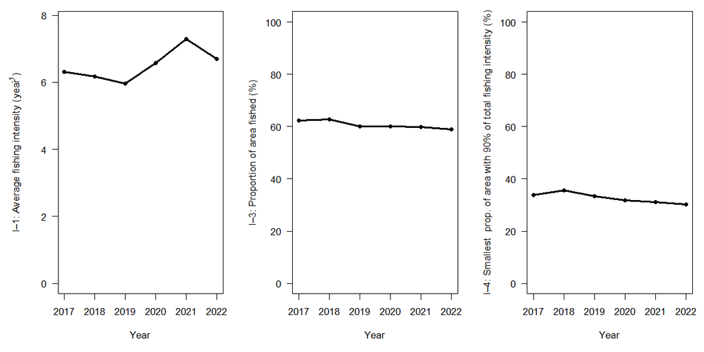

### Fishing by métier

#### Table 4

**Table 4. Landings weight and value by métier and their relationship with swept area in the Gulf of Cadiz subdivision.**

|  | OT_CRU | OT_DMF | OT_MI | DRB_MOL |
| --- | --- | --- | --- | --- |
| Area swept (×1000 km<sup>2</sup>) | 73.14 | 0.79 | 0.39 | 0.02 |
| Landings (×1000 tonnes) | 5.24 | 0.06 | 0.04 | 0.10 |
| Value (×10<sup>6</sup> euro) | NA | NA | NA | NA |
| Landings / Area swept (kg/km<sup>2</sup>) | 71.71 | 81.39 | 100.53 | 5274.40 |
| Value / Area swept (euro/km<sup>2</sup>) | NA | NA | NA | NA |

### Core fishing grounds

**Core fishing grounds could not be identified in this subdivision.**

### Impact

#### Figure 5

**Figure 5. The spatial distribution of MBCG fisheries impact in the Gulf of Cadiz subdivision, as assessed with the PD indicator (I‒6a) and PD-sens indicator (I‒6b), shown as annual means for the assessment period, evaluated at the c-square scale. Descriptions of the impact indicators are provided in the ‘Essential Information’ Table E1 in this document.**

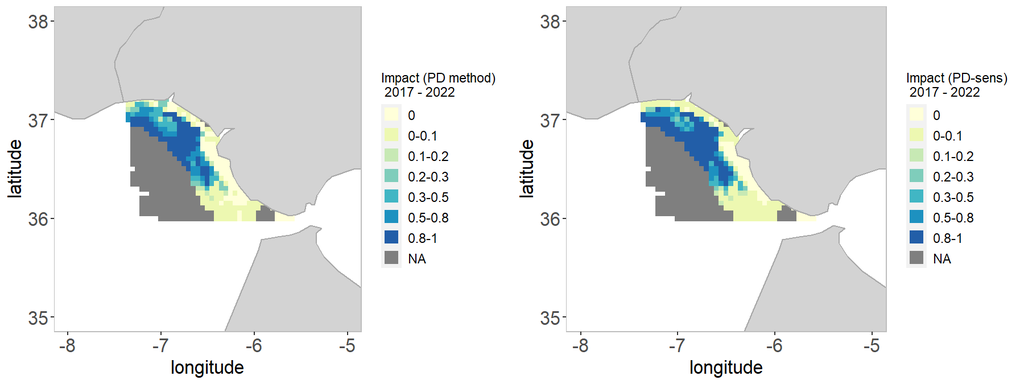

#### Figure 6

**Figure 6. Temporal variation in values of the PD indicator (I‒6a), PD-sens indicator (I‒6b), proportion of the extent with PD impact < 0.2 (I‒7a) and proportion of extent with PD-sens impact < 0.2 (I‒7b), shown for the overall area and for the four most extensive broad habitat types separately in the Gulf of Cadiz subdivision. Descriptions of the impact indicators are provided in the ‘Essential Information’ Table E1 in this document.**

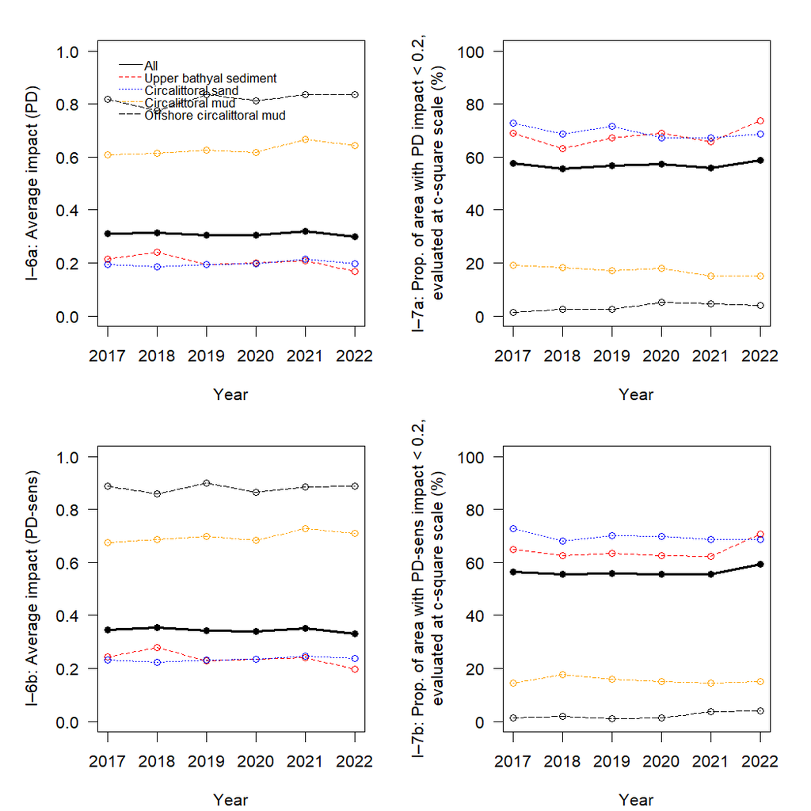

#### Table 5

**Table 5. Métier-specific landings weight and value per unit PD or PD-sens impact in the Gulf of Cadiz subdivision.**

|  | OT_CRU | OT_DMF | OT_MI | DRB_MOL |
| --- | --- | --- | --- | --- |
| Landings (tonnes)/PD impact | 36.0 | 57.7 | 59.7 | 36.6 |
| Value (×1000 euro)/PD impact | NA | NA | NA | NA |
| Landings (tonnes)/PD-sens impact | 32.3 | 45.1 | 63.1 | 47.9 |
| Value (×1000 euro)/PD-sens impact | NA | NA | NA | NA |

#### Figure 7

**Figure 7. Métier-related impacts, reported as annual means of the PD indicator (I‒6a, top) and PD-sens indicator (I‒6b, bottom), on the four most extensive broad habitat types in the Gulf of Cadiz subdivision.**

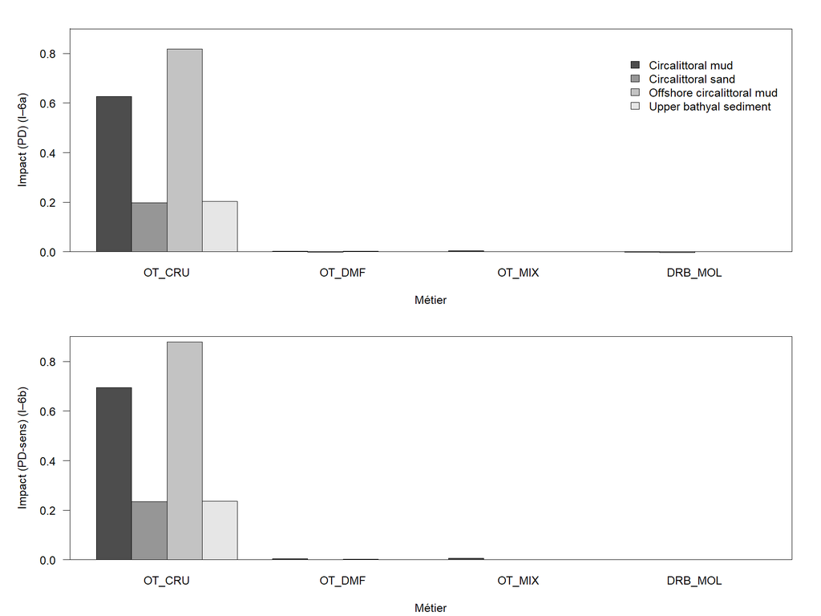

### Scenarios

#### Footprint reduction

##### Table 6: Effort

**Table 6. The effects of stepwise exclusion of all MBCG fisheries from a specified proportion of a MSFD broad habitat type within the Gulf of Cadiz subdivision, on swept area (presented as % of total swept area within that habitat type). The stepwise exclusion is conducted in 10% increments, and within each successive increment from 10% to 90% the c-squares with the lowest recorded rank MBCG swept area are excluded. Note that the top row shows the total estimate for all habitats combined.**

| MSFD broad habitat type | Extent of habitat (×1000 km<sup>2</sup>) | Total area swept (×1000 km<sup>2</sup> | 10% | 20% | 30% | 40% | 50% | 60% | 70% | 80% | 90% |
| --- | --- | --- | --- | --- | --- | --- | --- | --- | --- | --- | --- |
| total | 11.01 | 100 | 1.3 | 4.1 | 8.1 | 12.6 | 17.8 | 27.0 | 37.5 | 50.8 | 69.9 |
| Upper bathyal sediment | 4.08 | 11.62 | 0.0 | 0.0 | 0.0 | <0.1 | 1.4 | 5.5 | 13.0 | 23.2 | 41.2 |
| Circalittoral sand | 1.79 | 10.51 | 0.0 | <0.1 | <0.1 | 0.8 | 2.1 | 7.6 | 14.6 | 34.1 | 64.4 |
| Circalittoral mud | 1.72 | 25.68 | <0.1 | 3.6 | 9.2 | 14.6 | 20.9 | 31.3 | 42.2 | 54.9 | 72.0 |
| Offshore circalittoral mud | 1.28 | 20.81 | 3.4 | 8.5 | 14.3 | 21.9 | 29.8 | 41.4 | 55.2 | 66.8 | 83.2 |
| Offshore circalittoral sand | 0.57 | 0.94 | 2.2 | 7.6 | 13.0 | 20.4 | 28.3 | 37.8 | 48.8 | 61.8 | 78.0 |
| Infralittoral sand | 0.44 | 0.63 | 0.0 | 0.0 | 0.0 | <0.1 | <0.1 | 0.2 | 1.1 | 3.2 | 6.5 |
| Circalittoral mixed sediment | 0.15 | 1.64 | 1.3 | 3.4 | 6.5 | 9.1 | 16.0 | 27.3 | 50.3 | 73.4 | 100.0 |
| Infralittoral rock and biogenic reef | 0.14 | 0.01 | 0.0 | 0.0 | 0.0 | 0.0 | 0.0 | 0.0 | 0.0 | 0.0 | 9.1 |
| Circalittoral rock and biogenic reef | 0.13 | 0.05 | 0.0 | 0.0 | 0.0 | 0.0 | 0.0 | 0.0 | 2.7 | 16.4 | 55.8 |
| Infralittoral mixed sediment | 0.13 | 0.2 | <0.1 | <0.1 | <0.1 | <0.1 | 0.2 | 0.3 | 12.5 | 21.1 | 37.1 |
| Upper bathyal rock and biogenic reef | 0.12 | 0.09 | 0.0 | 0.0 | 0.0 | 0.2 | 1.7 | 7.1 | 16.5 | 65.8 | 86.6 |
| Infralittoral mud | 0.12 | 0.04 | 0.0 | 0.0 | 0.0 | <0.1 | <0.1 | 0.7 | 2.1 | 4.9 | 10.8 |
| Infralittoral coarse sediment | 0.1 | 0.1 | 0.0 | 0.0 | 0.1 | 0.1 | 0.4 | 0.9 | 3.1 | 40.2 | 40.2 |
| Circalittoral coarse sediment | 0.1 | 0.27 | <0.1 | 1.2 | 6.9 | 14.7 | 17.8 | 40.7 | 40.7 | 76.3 | 76.3 |
| Offshore circalittoral coarse sediment | 0.08 | 0.25 | 0.7 | 1.7 | 3.5 | 8.4 | 8.4 | 15.9 | 20.7 | 40.0 | 100.0 |
| Offshore circalittoral mixed sediment | 0.06 | 1.44 | 12.4 | 16.3 | 29.7 | 37.9 | 46.2 | 69.6 | 69.6 | 82.9 | 100.0 |
| Unknown | 0 | 0 | 0.0 | 0.0 | 0.0 | 0.0 | 0.0 | 0.0 | 33.1 | 33.1 | 33.1 |

##### Table 7: Landings weight

**Table 7. The effects of stepwise exclusion of all MBCG fisheries from a specified proportion of a MSFD broad habitat type within the Gulf of Cadiz subdivision, on landings weight (presented as % of total landings weight within that habitat type). The stepwise exclusion is conducted in 10% increments, and within each successive increment from 10% to 90% the c-squares with the lowest recorded rank MBCG swept area are excluded. Note that the top row shows the total estimate for all habitats combined.**

| MSFD broad habitat type | Extent of habitat (×1000 km<sup>2</sup>) | Total landings weight (×1000 kg) | 10% | 20% | 30% | 40% | 50% | 60% | 70% | 80% | 90% |
| --- | --- | --- | --- | --- | --- | --- | --- | --- | --- | --- | --- |
| Total | 11.01 | 5438.9 | 1.7 | 4.6 | 8.8 | 13.1 | 18.4 | 27.8 | 39.0 | 52.9 | 71.3 |
| Upper bathyal sediment | 4.08 | 960.5 | 0.0 | 0.0 | 0.0 | 0.1 | 1.4 | 6.3 | 14.9 | 26.0 | 43.7 |
| Circalittoral sand | 1.79 | 797.8 | 0.0 | <0.1 | 1.6 | 2.8 | 5.7 | 12.8 | 20.5 | 43.0 | 70.3 |
| Circalittoral mud | 1.72 | 1711.3 | 1.5 | 5.3 | 11.3 | 16.4 | 22.6 | 32.5 | 44.4 | 56.3 | 72.4 |
| Offshore circalittoral mud | 1.28 | 1451.9 | 3.4 | 8.6 | 14.3 | 22.0 | 30.2 | 42.2 | 55.8 | 67.3 | 84.2 |
| Offshore circalittoral sand | 0.57 | 77.8 | 3.3 | 12.6 | 20.0 | 28.5 | 36.2 | 44.9 | 55.5 | 65.3 | 82.2 |
| Infralittoral sand | 0.44 | 68.1 | 0.0 | 0.0 | 0.0 | 0.1 | 4.8 | 9.9 | 37.4 | 40.5 | 44.7 |
| Circalittoral mixed sediment | 0.15 | 140.6 | 1.8 | 4.4 | 9.0 | 12.5 | 19.0 | 26.4 | 47.5 | 73.0 | 100.0 |
| Infralittoral rock and biogenic reef | 0.14 | 1.3 | 0.0 | 0.0 | 0.0 | 0.0 | 0.0 | 0.0 | 0.0 | 0.0 | 7.2 |
| Circalittoral rock and biogenic reef | 0.13 | 7.7 | 0.0 | 0.0 | 0.0 | 0.0 | 0.0 | 0.0 | 2.9 | 15.9 | 60.3 |
| Infralittoral mixed sediment | 0.13 | 23.9 | 0.4 | 1.3 | 3.8 | 3.8 | 7.0 | 10.3 | 27.0 | 35.6 | 58.3 |
| Upper bathyal rock and biogenic reef | 0.12 | 7.6 | 0.0 | 0.0 | 0.0 | 0.2 | 1.8 | 8.8 | 18.7 | 68.5 | 87.9 |
| Infralittoral mud | 0.12 | 17.1 | 0.0 | 0.0 | 0.0 | 0.2 | 1.0 | 8.4 | 24.5 | 73.5 | 75.5 |
| Infralittoral coarse sediment | 0.1 | 17.2 | 0.0 | 0.0 | 5.8 | 5.8 | 11.5 | 30.8 | 32.7 | 69.8 | 69.8 |
| Circalittoral coarse sediment | 0.1 | 32.8 | 2.2 | 3.2 | 9.2 | 18.2 | 23.5 | 52.0 | 52.0 | 89.4 | 89.4 |
| Offshore circalittoral coarse sediment | 0.08 | 23.3 | 1.0 | 2.7 | 4.8 | 10.7 | 10.7 | 19.7 | 24.3 | 42.1 | 100.0 |
| Offshore circalittoral mixed sediment | 0.06 | 100.1 | 13.0 | 16.6 | 29.9 | 38.6 | 46.1 | 68.9 | 68.9 | 82.1 | 100.0 |
| Unknown | 0 | 0 | 0.0 | 0.0 | 0.0 | 0.0 | 0.0 | 0.0 | 48.2 | 48.2 | 48.2 |

##### Table 8: Landings value

**Table 8. The effects of stepwise exclusion of all MBCG fisheries from a specified proportion of a MSFD broad habitat type within the Gulf of Cadiz subdivision, on landings value (presented as % of total landings value within that habitat type). The stepwise exclusion is conducted in 10% increments, and within each successive increment from 10% to 90% the c-squares with the lowest recorded rank MBCG swept area are excluded. Note that the top row shows the total estimate for all habitats combined.**

| MSFD broad habitat type | Extent of habitat (×1000 km<sup>2</sup>) | Total landings value (×1000 euro) | 10% | 20% | 30% | 40% | 50% | 60% | 70% | 80% | 90% |
| --- | --- | --- | --- | --- | --- | --- | --- | --- | --- | --- | --- |
| Total | 11.01 | NA | NA | NA | NA | NA | NA | NA | NA | NA | NA |
| Upper bathyal sediment | 4.08 | NA | NA | NA | NA | NA | NA | NA | NA | NA | NA |
| Circalittoral sand | 1.79 | NA | NA | NA | NA | NA | NA | NA | NA | NA | NA |
| Circalittoral mud | 1.72 | NA | NA | NA | NA | NA | NA | NA | NA | NA | NA |
| Offshore circalittoral mud | 1.28 | NA | NA | NA | NA | NA | NA | NA | NA | NA | NA |
| Offshore circalittoral sand | 0.57 | NA | NA | NA | NA | NA | NA | NA | NA | NA | NA |
| Infralittoral sand | 0.44 | NA | NA | NA | NA | NA | NA | NA | NA | NA | NA |
| Circalittoral mixed sediment | 0.15 | NA | NA | NA | NA | NA | NA | NA | NA | NA | NA |
| Infralittoral rock and biogenic reef | 0.14 | NA | NA | NA | NA | NA | NA | NA | NA | NA | NA |
| Circalittoral rock and biogenic reef | 0.13 | NA | NA | NA | NA | NA | NA | NA | NA | NA | NA |
| Infralittoral mixed sediment | 0.13 | NA | NA | NA | NA | NA | NA | NA | NA | NA | NA |
| Upper bathyal rock and biogenic reef | 0.12 | NA | NA | NA | NA | NA | NA | NA | NA | NA | NA |
| Infralittoral mud | 0.12 | NA | NA | NA | NA | NA | NA | NA | NA | NA | NA |
| Infralittoral coarse sediment | 0.1 | NA | NA | NA | NA | NA | NA | NA | NA | NA | NA |
| Circalittoral coarse sediment | 0.1 | NA | NA | NA | NA | NA | NA | NA | NA | NA | NA |
| Offshore circalittoral coarse sediment | 0.08 | NA | NA | NA | NA | NA | NA | NA | NA | NA | NA |
| Offshore circalittoral mixed sediment | 0.06 | NA | NA | NA | NA | NA | NA | NA | NA | NA | NA |
| Unknown | 0 | NA | NA | NA | NA | NA | NA | NA | NA | NA | NA |

#### Gear modifications

##### Figure 8: Habitat 1

**Figure 8. Effects of gear modifications (5%, 10%, and 20% lower depletion) on the quality-extent relationship for the most abundant MSFD habitat type in the Gulf of Cadiz subdivision. Habitat quality is defined as 1 - impact, with impact calculated as PD (I‒6a) or PD-sens (I‒7a). The dotted line represent the extent threshold of 75% for the proportion of a broad habitat type that should not be adversely affected (EU, 2024).**

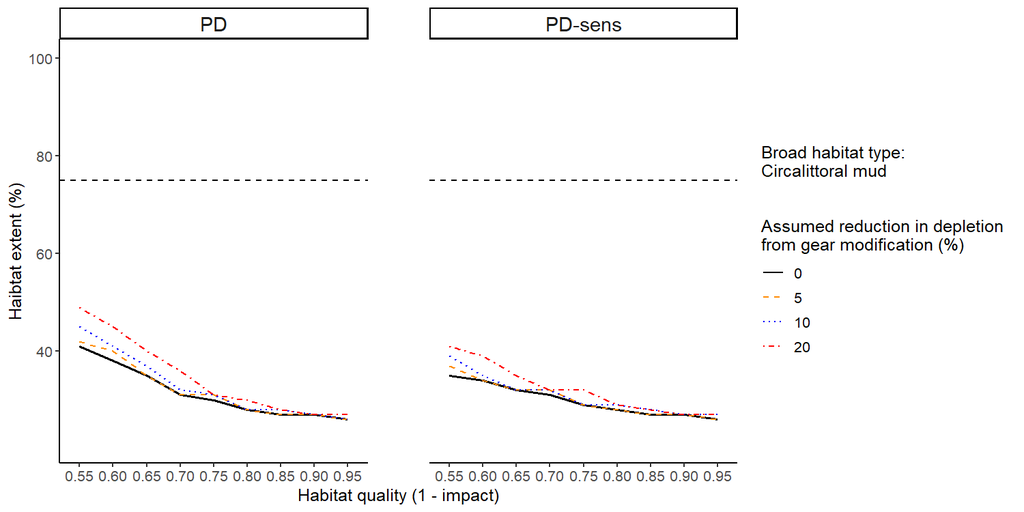

##### Figure 9: Habitat 2

**Figure 9. Effects of gear modifications (5%, 10%, and 20% lower depletion) on the quality-extent relationship for the most abundant MSFD habitat type in the Gulf of Cadiz subdivision. Habitat quality is defined as 1 - impact, with impact calculated as PD (I‒6a) or PD-sens (I‒7a). The dotted line represent the extent threshold of 75% for the proportion of a broad habitat type that should not be adversely affected (EU, 2024).**

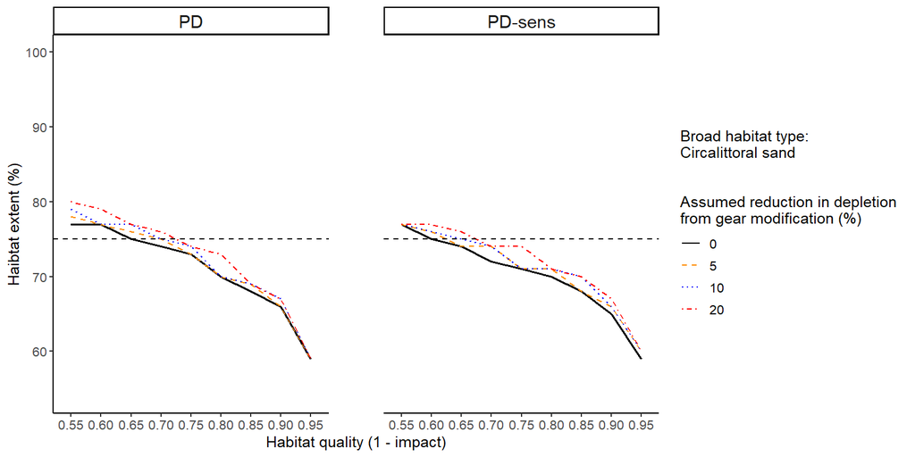

##### Figure 10: Habitat 3

**Figure 10. Effects of gear modifications (5%, 10%, and 20% lower depletion) on the quality-extent relationship for the most abundant MSFD habitat type in the Gulf of Cadiz subdivision. Habitat quality is defined as 1 - impact, with impact calculated as PD (I‒6a) or PD-sens (I‒7a). The dotted line represent the extent threshold of 75% for the proportion of a broad habitat type that should not be adversely affected (EU, 2024).**

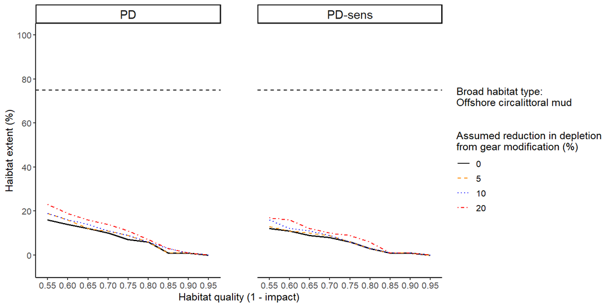

##### Figure 11: Habitat 4

**Figure 11. Effects of gear modifications (5%, 10%, and 20% lower depletion) on the quality-extent relationship for the most abundant MSFD habitat type in the Gulf of Cadiz subdivision. Habitat quality is defined as 1 - impact, with impact calculated as PD (I‒6a) or PD-sens (I‒7a). The dotted line represent the extent threshold of 75% for the proportion of a broad habitat type that should not be adversely affected (EU, 2024).**

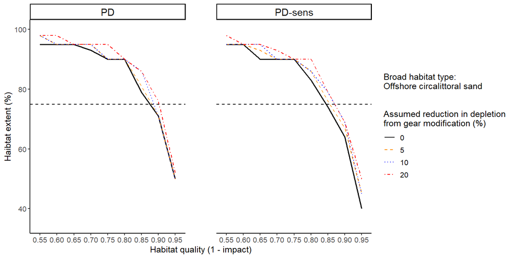

## Essential information

**Content of this advice product**

This interactive document presents information on the distribution, intensity, impact, landings weight, and landings value of mobile bottom-contacting gear (MBCG) fisheries within the Bay of Biscay and the Iberian Coast area and the estimated consequences and costs (expressed as loss of landings weight and value) of reducing the relative extent of areas fished with MBCG. The information is from an assessment for the Bay of Biscay and the Iberian Coast area for the period 2017‒2022. The six-year period was selected to include the latest available vessel monitoring system (VMS) and logbook data rather than to match a specific Marine Strategy Framework Directive (MSFD) assessment period (EU, 2008). The assessment describes fishing intensity and impact with five pressure indicators and four benthic impact indicators (Table E1).

**Table E1. Pressure and impact indicators, including the spatial scale and period for which indicators are evaluated. C-square refers to a grid cell of dimensions 0.05° latitude × 0.05° longitude. Examples of the “defined area” referred to in the description would be an area within a specified depth range or an area with the same BHT.**

[output not shown]

For each defined assessment area and subdivision, sections of this interactive document provide “summary” information and information on “fishing intensity”, “core fishing grounds”, “fishing by métier”, “impact”, and “scenarios” (Table E2).

**Table E2. Information provided in the tabs for each assessment area.**

Tab

Description

Summary

- Values of pressure indicators I‒1 to I‒5 and impact indicators I‒6a, I‒6b, I‒7a and I‒7b by depth strata (Table 1).
- Maps of swept area ratio, median longevity of benthic fauna, and landings value and weight (Figure 1).
- Estimates of the contribution of small-scale fisheries (MBCG vessels < 12 m overall length) to total fishing effort in kW × days (Table 2).

Fishing intensity

- The extent of broad habitat types, and various estimates of MBCG fishing activity for these habitat types; fisheries landings, value, and intensity (Table 3).
- Temporal variation of pressure indicators I‒1, I‒3, and I‒4 (Figure 2).

Fishing by métier

- Estimates of swept area, landings weight, and landings value for the active métiers (Table 4).

Core fishing grounds

- Spatial stability of core fishing grounds (smallest area responsible for 90% of the landings value) over time (Figure 3).
- Spatial distribution of the stability of core fishing grounds (Figure 4).

Impact

- Spatial distribution of MBCG fisheries impact indicator values (I‒6a) and (I‒6b) (Figure 5).
- Temporal variation of impact indicators I‒6a, I‒6b, I‒7a, and I‒7b (Figure 6).
- Landings weight and value per unit impact for the active métiers (Table 5).
- Métier-specific impacts for the four most extensive broad habitat types (Figure 7).

Scenarios

**Assessment area**

**Figure E1. Map of the assessment area, showing the water depth class distributions (left), and boundaries of the relevant (MSFD) divisions and FAO regions (right).**

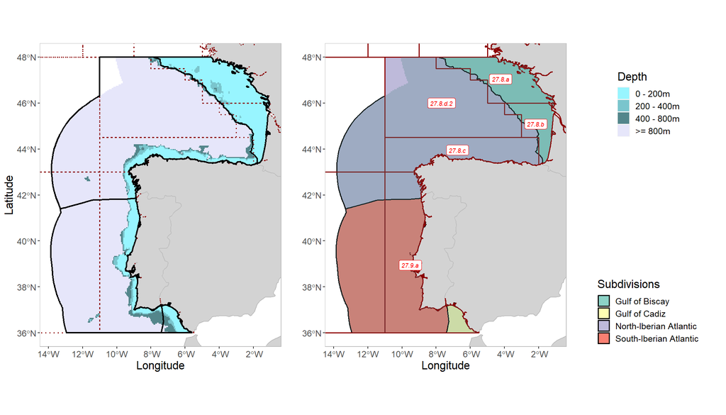

**Limitations of this advice**

Data and analytical limitations are described in the “Limitations” section of the main advice text. This text should be consulted before viewing this interactive document.

**How is fishing intensity evaluated?**

Five pressure indicators were used to describe fishing intensity and distribution resulting from the use of MBCG (Table E1).

These indicators are calculated, for any given area as defined in this document, from estimates of the swept area in each of the c-squares within a defined area of interest. The swept area is calculated as hours fished × average fishing speed × gear width. This requires that VMS location records are linked to logbook data to associate a location and speed with gear code and fishing activity (Data Collection Framework level 4 and 6 respectively). VMS locations are allocated to “fishing” and “not fishing” based on vessel speed and other filters (ICES, 2022). The gear width is estimated based on relationships between average gear widths and average vessel length or engine power (kW; Eigaard et al. 2016; ICES, 2022). The swept-area ratio (SAR) is calculated as the sum of the area swept by a defined set of MBCG in a defined area (usually one c-square) in a defined period (usually one year) divided by the area of the defined area. Therefore, when calculated at the c-square scale, the SAR indicates the theoretical number of times the c-square is swept per year, assuming that the MBCG fishing is evenly distributed over the c-square. For example, a SAR of 2 means that the entire c-square is fished two times over the year, a SAR of 0.5 means that the entire c-square is fished once in two years.

**How is benthic impact evaluated?**

Four indicators were used to describe benthic impacts. These indicators are generated from the assessment methods PD and PD-sens. PD (population dynamics method) is used to estimate the loss of benthic biomass, relative to carrying capacity, from a defined area if the current MBCG fishing intensity continues indefinitely (Pitcher et al., 2017; ICES, 2018; Hiddink et al., 2019; ICES, 2022). PD-sens (population dynamics method for sensitive fauna) is used to estimate the loss of biomass of sensitive benthic fauna (the 10% most long-lived biomass fraction), relative to carrying capacity, from a defined area if the current MBCG fishing intensity continues indefinitely (ICES, 2024). For this advice, PD and PD-sens are estimated at the c-square scale.

PD and PD-sens are estimated from SAR and parameters for depletion (proportional mortality) per pass of a MBCG and the intrinsic rate of increase of biomass of the benthic community (Pitcher et al. 2017). Estimates of depletion were métier-specific and taken from Rijnsdorp et al (2020). The intrinsic rate of increase is estimated from the predicted local distribution of maximum ages in an unimpacted benthic community (Rijnsdorp et al., 2018). When PD-sens rather than PD is calculated, only the 10% most long-lived biomass fraction of this community is used to estimate the intrinsic rate of increase, to address the component of the benthic biomass most sensitive to MBCG.

**How are landings values evaluated?**

VMS location records are linked to logbook data to associate a location with gear code and fishing activity (Data Collection Framework level 4 and 6 respectively), and with landings weight and landings value records. VMS location records are classified as “fishing” and “not fishing” based on vessel speed and other filters (ICES, 2022). Landings weight and value are then allocated to the VMS location records classified as fishing, based on the time interval between location records or an equal split among location records by day, by ICES rectangle or by trip. Total landings weight or value by c-square, in a given time-interval, are calculated as the sum of the allocations to each location record in that c-square.

**References**

Eigaard O. R., Bastardie F., Breen M. l., Dinesen G. E., Laffargue P., Mortensen, J., et al. 2016. Estimating seafloor pressure from trawls and dredges based on gear design and dimensions. ICES Journal of Marine Science 73(1): 27−43 https://doi.org/10.1093/icesjms/fsv099

EU. 2008. Directive 2008/56/EC of the European Parliament and of the Council of 17 June 2008 establishing a framework for community action in the field of marine environmental policy (Marine Strategy Framework Directive) (Text with EEA relevance). Official Journal of the European Union L164, 19−40. http://data.europa.eu/eli/dir/2008/56/oj

Hiddink, J. G., Jennings, S., Sciberras, M., Bolam, S. G., Cambiè, G., McConnaughey, R. A., Mazor, T., et al. 2019 Assessing bottom-trawling impacts based on the longevity of benthic invertebrates. Journal of Applied Ecology, 56: 1075–1083. https://doi.org/10.1111/1365-2664.13278

ICES. 2018. Interim Report of the Working Group on Fisheries Benthic Impact and Trade-offs (WGFBIT), 12–16 November 2018, ICES Headquarters, Copenhagen, Denmark. ICES CM 2018/HAPISG:21. 74 pp.

ICES. 2022. Working Group on Fisheries Benthic Impact and Trade-offs (WGFBIT; outputs from 2021meeting). ICES Scientific Reports. 4:9. 133 pp. http://doi.org/10.17895/ices.pub.10042

Pitcher, C. R., Ellis, N., Jennings, S., Hiddink, J. G., Mazor, T., Kaiser, M. J., Kangas, M. I., et al. 2017. Estimating the sustainability of towed fishing-gear impacts on seabed habitats: a simple quantitative risk assessment method applicable to data-limited fisheries. Methods in Ecology and Evolution. 8: 472–480. https://doi.org/10.1111/2041-210X.12705.

Rijnsdorp, A. D., Bolam, S. G., Garcia, C., Hiddink, J. G., Hintzen, N. T., van Denderen, D. P., and Van Kooten, T. 2018. Estimating sensitivity of seabed habitats to disturbance by bottom trawling based on the longevity of benthic fauna. Ecological Applications, 28: 1302–1312. https://doi.org/10.1002/eap.1731

Rijnsdorp, A. D., Hiddink, J. G., van Denderen, P. D., Hintzen, N. T., Eigaard, O. R., Valanko, S., Bastardie, F., et al. 2020. Different bottom trawl fisheries have a differential impact on the status of the North Sea seafloor habitats. ICES Journal of Marine Science. 77(5): 1772–86. https://doi.org/10.1093/icesjms/fsaa050